# MRD/PET-CT Concordance — Analysis Report

Max Mendez et al

2026-03-26

# 1 Overview & Summary

This report reproduces the MRD/PET-CT concordance and prognostic analyses from paired study-level data in multiple myeloma. Where needed, reported percentages were converted back to cell counts and reconciled to the reported sample size. The main analysis includes paired MRD and PET-CT assessments at the same clinical landmark, with additional sensitivity analyses for stricter timing and reconstruction assumptions.All inputs are harmonised: a = MRD−/PET–CT+, b = MRD−/PET–CT−, c = MRD+/PET–CT−, d = MRD+/PET–CT+.

Analysis sets: (i) Primary (paired MRD and PET–CT assessments at the same clinical landmark); (ii) Strict pairing sensitivity set (Δ ≤ 30 days between MRD and PET–CT); and (iii) prespecified sensitivity analyses based on reconstruction assumptions and risk-of-bias exclusions.

Agreement metrics: Per study we report observed agreement (pooled concordant proportion), Cohen’s κ (with standard error and 95% confidence interval), McNemar’s test, and complementary prevalence-robust agreement measures (Gwet’s AC1 and prevalence-adjusted bias-adjusted κ [PABAK]). Study-level κ is pooled using random-effects meta-analysis (restricted maximum likelihood) with Knapp–Hartung adjustment. Directional discordance is defined as the log-odds of MRD−/PET–CT+ versus MRD+/PET–CT− discordant classifications, using a continuity correction where needed; 95% prediction intervals are reported when estimable.

Fréchet–Hoeffding κ bounds: Identification regions are derived for studies with incomplete 2×2 information and presented as supplementary graphical analyses to support cautious interpretation where κ is only weakly identified.

Survival (progression-free survival, PFS): The primary prognostic contrast is dual negativity (MRD−/PET–CT−) versus all other MRD/PET–CT categories. Hazard ratios (HRs) are pooled using random-effects meta-analysis (restricted maximum likelihood) with Knapp–Hartung adjustment. Small-study asymmetry assessments are interpreted descriptively given the limited number of cohorts.

Primary pooled 2×2 matrix (paired same-landmark set): MRD−/PET–CT+ 145 (12.7%), MRD−/PET–CT− 499 (43.8%), MRD+/PET–CT− 310 (27.2%), and MRD+/PET–CT+ 184 (16.2%); total paired n=1,138. Observed agreement = 60.0%, pooled κ = 0.14 (95% CI 0.03–0.25), and pooled directional discordance log-odds = −0.83 (95% CI −1.87 to 0.21). In five studies reporting PFS by joint MRD/PET–CT status, the pooled HR for dual-negative versus all other categories is 0.34 (95% CI 0.22–0.51).

Key outputs: Table 1 (study characteristics); Figure 1 (PRISMA flow diagram); Figure 2A (agreement meta-analysis, Cohen’s κ); Figure 2B (directional discordance meta-analysis); Figure 3 (PFS meta-analysis); and supplementary analyses covering strict pairing, Fréchet–Hoeffding bounds, small-study effects, and risk of bias.

```
*Figure S1 omitted: simulation unavailable.**Figure S2 omitted: DCA inputs unavailable.*
```

```
*Table S1 omitted: could not compute FH bounds.*
```

# 2 Study Selection

## 2.1 Figure 1. PRISMA Diagram

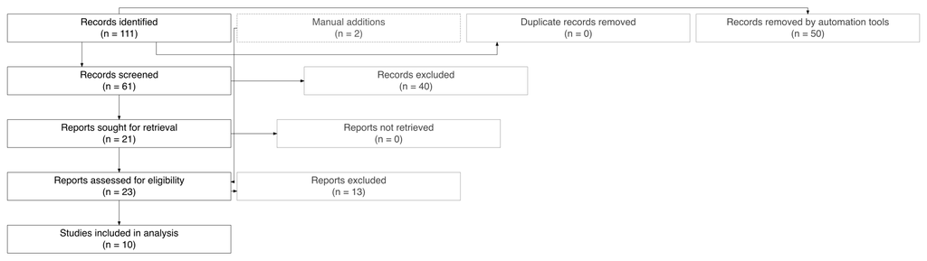

## 2.2 Table 1. Study Characteristics

|  | Study | Year | N | MRD platform | PET criteria | Simultaneous MRD and PET/CT Assessments | HR available |
| --- | --- | --- | --- | --- | --- | --- | --- |
| 1 | Alonso R et al 2019 | 2019 | 103 | Flow cytometry (1.00E-04) | Italian MM imaging criteria (IMPeTUs) | Yes | Yes |
| 2 | Moreau, P et al, 2019; Kraeber et al 2025-CASSIOPET | 2019 | 176 | Flow cytometry (1.00E-05) | Italian MM imaging criteria (IMPeTUs) |  | Yes |
| 3 | Zamagni E et al 2021 | 2021 | 228 | NGF (8-color, BM) (1e-5, 1e-6) | Italian MM imaging criteria (IMPeTUs) | Yes | No/NA |
| 4 | Broeckle D et al 2022 | 2022 | 78 | Flow cytometry (1.00E-06) | ESMO-IMWG 2021 standard imaging criteria | Yes | No/NA |
| 5 | Fonseca R et al 2023 | 2023 | 136 | NGS (clonoSEQ) (1.00E-06) | Binary (+/-), radiologist read | Yes | Yes |
| 6 | Kraeber BF et al 2023-CASSIOPET | 2023 | 184 | Flow cytometry (1.00E-05) | Italian MM imaging criteria (IMPeTUs) |  | No/NA |
| 7 | Mookerjee A et al 2023 | 2023 | 131 | Flow cytometry (1.00E-06) | DS 2-3 = negative, DS 4 = positive | Yes | Yes |
| 8 | Noogaard JN et al 2023 | 2023 | 159 | NGF (8-color, BM) (1.00E-05) | Italian MM imaging criteria (IMPeTUs) | No/NA | No/NA |
| 9 | Zamagni E et al 2023 | 2023 | 109 | Flow cytometry (1.00E-05) | Italian MM imaging criteria (IMPeTUs) | Yes | Yes |
| 10 | Hajiyianni M et al 2024 | 2024 | 72 | Flow cytometry (1.00E-05) | Italian MM imaging criteria (IMPeTUs) |  | No/NA |

[output cut: 2 more lines]

## 2.3 Supplementary Table ST1. Complete Log-Screen

| Details: click to expand | Source | Title | Authors | Year | Journal | DOI | Decision After First Scanning | Selected for Full Text Review | Included after Full Text Review | Reason for First Decision | Authors_full | Abstract_full | Reason_full | Decision_full |
| --- | --- | --- | --- | --- | --- | --- | --- | --- | --- | --- | --- | --- | --- | --- |
| &oplus; |  | Daratumumab-based quadruplet for patients with extramedullary multiple myeloma: Results from the Phase II prospective EMN19 study. | Meral Beksac, Tulin Fıratlı Tuglular, Francesca Gay, Roberto Mina, Eirini Katodritou, Ali Unal, Michele Cavo, Guner Hayri Ozsan, Vincent H J van der Velden, Berna H Beverloo, Michael Vermeulen, Mark v… | 2026 | Hemasphere |  | Maybe | No |  | Original prospective MM cohort with PET/CT + marrow MRD + outcomes, but abstract lacks joint PET/MRD strata (2×2) for concordance | Meral Beksac, Tulin Fıratlı Tuglular, Francesca Gay, Roberto Mina, Eirini Katodritou, Ali Unal, Michele Cavo, Guner Hayri Ozsan, Vincent H J van der Velden, Berna H Beverloo, Michael Vermeulen, Mark v… | Novel therapies are needed for patients with multiple myeloma (MM) and extramedullary plasmacytomas. The prospective, Phase II EMN19 study assessed the efficacy and safety of daratumumab plus bortezom… | Original prospective MM cohort with PET/CT + marrow MRD + outcomes, but abstract lacks joint PET/MRD strata (2×2) for concordance | No |
| &oplus; |  | Precision radiolabeled B-cell maturation nanobody for targeted PET imaging and radioligand therapy of disseminated multiple myeloma. | Ghaemi B, Olkowski CP, Basuli F, Shi J, Young R, Kazandjian D, Landgren O, Hill E, Choyke PL, Jacobson O | 2026 | Theranostics |  | Exclude | No |  | Preclinical/animal theranostic development; no human MM cohort, no clinical outcomes | Ghaemi B, Olkowski CP, Basuli F, Shi J, Young R, Kazandjian D, Landgren O, Hill E, Choyke PL, Jacobson O | Background: Multiple myeloma (MM) is an incurable plasma cell malignancy with limited disease-specific imaging options. Current diagnostic methods often fail to detect early disease states and minimal… | Preclinical/animal theranostic development; no human MM cohort, no clinical outcomes | No |
| &oplus; |  | Analysis of discordant results in multi-technique platform-based MRD detection in multiple myeloma and the clinical decision-making dilemma. | Chen X, Zheng H, Cong X, Wang N, Zhang L, Li L | 2026 | Leuk Lymphoma |  | Exclude | No |  | Review article or guideline, no original patient data | Chen X, Zheng H, Cong X, Wang N, Zhang L, Li L | The evaluation of measurable residual disease (MRD) in multiple myeloma now integrates multiple techniques, including next-generation flow cytometry (NGF), next-generation sequencing (NGS), PET/CT, an… | Review article or guideline, no original patient data | No |
| &oplus; |  | Treatment response assessment using whole body diffusion weighted-magnetic resonance imaging in myeloma: a retrospective cohort study. | Chakraborty R, Shalaby K, Parker S, Lala S, Beylergil V, Alberico R, Bhutani D, Hillengass J, Lentzsch S | 2026 | Leuk Lymphoma |  | Exclude | No |  | WB DW-MRI response assessment (not PET/CT-based); not eligible for PET/CT–MRD concordance/prognosis framework | Chakraborty R, Shalaby K, Parker S, Lala S, Beylergil V, Alberico R, Bhutani D, Hillengass J, Lentzsch S | This bi-institutional retrospective cohort study evaluated whole-body diffusion-weighted MRI (WB DW-MRI) for myeloma response assessment and its concordance with bone marrow minimal residual disease (… | WB DW-MRI response assessment (not PET/CT-based); not eligible for PET/CT–MRD concordance/prognosis framework | No |
| &oplus; |  | Validation of novel low-dose CT methods for quantifying bone marrow in the appendicular skeleton of patients with multiple myeloma: initial results from the [(18)F]FDG PET/CT sub-study of the Phase 3 … | Sachpekidis C, Hajiyianni M, Grözinger M, Piller M, Kopp-Schneider A, Mai EK, John L, Sauer S, Weinhold N, Menis E, Enqvist O, Raab MS, Jauch A, Edenbrandt L, Hundemer M, Brobeil A, Jende J, Schlemmer… | 2026 | Eur J Nucl Med Mol Imaging |  | Exclude | No |  | PET/CT sub-study focused on CT quantification/IMPeTUs correlations; no extractable PET/CT–marrow MRD joint strata or survival outcomes for this review | Sachpekidis C, Hajiyianni M, Grözinger M, Piller M, Kopp-Schneider A, Mai EK, John L, Sauer S, Weinhold N, Menis E, Enqvist O, Raab MS, Jauch A, Edenbrandt L, Hundemer M, Brobeil A, Jende J, Schlemmer… | Purpose: The clinical significance of medullary abnormalities in the appendicular skeleton detected by computed tomography (CT) in patients with multiple myeloma (MM) remains incompletely elucidated. … | PET/CT sub-study focused on CT quantification/IMPeTUs correlations; no extractable PET/CT–marrow MRD joint strata or survival outcomes for this review | No |
| &oplus; |  | Progression-Free and Overall Survival After KRd Consolidation in FDG PET/CT Positive Patients After ASCT: A Phase II Study (CONPET). | Nørgaard JN, Abildgaard N, Lysén A, Tsykunova G, Vangsted AJ, João C, Remen N, Osnes L, Stokke C, Connelly JP, Revheim MR, Schjesvold F | 2025 | Clin Lymphoma Myeloma Leuk |  | Include | Yes |  | Clinical Phase II study with PET/CT status + marrow MRD and survival endpoints; likely extractable prognostic comparisons | Nørgaard JN, Abildgaard N, Lysén A, Tsykunova G, Vangsted AJ, João C, Remen N, Osnes L, Stokke C, Connelly JP, Revheim MR, Schjesvold F | Background: In multiple myeloma, 18F-Fluorodeoxyglucose (FDG) positron emission tomography (PET) positivity after first-line autologous stem cell transplantation (ASCT) is associated with reduced prog… | Clinical Phase II study with PET/CT status + marrow MRD and survival endpoints; likely extractable prognostic comparisons | Yes |
| &oplus; |  | B-cell maturation antigen targeted PET/CT imaging in multiple myeloma: a first-in-human study. | Gu T, Chen Z, Wang T, Dong Y, Kang L | 2025 | J Hematol Oncol |  | Maybe | No |  | Moved to 'Maybe'. First-in-human BCMA PET/CT; MRD mentioned but unclear whether marrow MRD testing/joint strata are reported | Gu T, Chen Z, Wang T, Dong Y, Kang L | B-cell maturation antigen (BCMA)-targeted positron emission tomography/computed tomography (PET/CT) represents a promising tool for the management of multiple myeloma, enabling noninvasive and quantit… | Moved to 'Maybe'. First-in-human BCMA PET/CT; MRD mentioned but unclear whether marrow MRD testing/joint strata are reported | No |
| &oplus; |  | Treatment Accessibility, Availability, and Healthcare Costs for Multiple Myeloma in South Asian Countries. | Yanamandra U, Raphael C, Peela R, Saleh AJM, Dorji T, Juneh H, Gyi AA, Jha A, Mir MA, Somawardana B, Kabir AL, Poudyal B, Wimalachandra M, Aziz Z, Williams S, Usmani S, Kumar S, Malhotra P | 2025 | Clin Lymphoma Myeloma Leuk |  | Exclude | No |  | Health-systems/cost survey; not PET/CT–MRD concordance or prognostic outcomes | Yanamandra U, Raphael C, Peela R, Saleh AJM, Dorji T, Juneh H, Gyi AA, Jha A, Mir MA, Somawardana B, Kabir AL, Poudyal B, Wimalachandra M, Aziz Z, Williams S, Usmani S, Kumar S, Malhotra P | Background: Multiple myeloma (MM) is a hematological malignancy with rising incidence globally, including in South Asia. Despite advances in treatment, access to essential drugs, diagnostic tools, and… | Health-systems/cost survey; not PET/CT–MRD concordance or prognostic outcomes | No |
| &oplus; |  | Prognostic value of premaintenance FDG PET/CT response in patients with newly diagnosed myeloma from the CASSIOPEIA trial. | Kraeber-Bodéré F, Jamet B, Zweegman S, Perrot A, Hulin C, Caillot D, Facon T, Leleu X, Belhadj K, Itti E, Karlin L, Bailly C, Levin MD, Minnema MC, Bodet-Milin C, de Keizer B, Corre J, Sonneveld P, Mo… | 2025 | Blood |  | Include | No |  | CASSIOPET/CASSIOPEIA companion study: PET/CT response + marrow MRD with PFS/OS; key prognostic dataset | Kraeber-Bodéré F, Jamet B, Zweegman S, Perrot A, Hulin C, Caillot D, Facon T, Leleu X, Belhadj K, Itti E, Karlin L, Bailly C, Levin MD, Minnema MC, Bodet-Milin C, de Keizer B, Corre J, Sonneveld P, Mo… | The CASSIOPEIA trial demonstrated superior progression-free survival (PFS) with the addition of daratumumab to bortezomib, thalidomide, and dexamethasone (D-VTd) induction/consolidation, and with dara… | CASSIOPET/CASSIOPEIA companion study: PET/CT response + marrow MRD with PFS/OS; key prognostic dataset | No |
| &oplus; |  | Role of Composite Measurable Residual Disease Assessment with PET-CT and flow cytometry in Multiple Myeloma patients undergoing Autologous Transplant. | Swain RN, Jain A, Wadhera S, Jandial A, Singh C, Lad D, Prakash G, Khadwal A, Sreedharuni S, Sachdeva MUS, Basher RK, Das R, Malhotra P | 2025 | Blood Cell Ther |  | Include | Yes |  | Original cohort using composite MRD (PET-CT + marrow flow) with prognostic endpoints (TTNT/OS) | Swain RN, Jain A, Wadhera S, Jandial A, Singh C, Lad D, Prakash G, Khadwal A, Sreedharuni S, Sachdeva MUS, Basher RK, Das R, Malhotra P | Background: Bone marrow (BM) Measurable Residual Disease (MRD) assessments underestimate disease burden in multiple myeloma, as focal lesions can exist outside the marrow. Functional imaging, like pos… | Original cohort using composite MRD (PET-CT + marrow flow) with prognostic endpoints (TTNT/OS) | Yes |

[output cut: 115 more lines]

# 3 Concordance analysis

## 3.1 Table 2. Concordance: κ and McNemar

|  | Study | n | MRD-/PET+ | MRD-/PET- | MRD+/PET- | MRD+/PET+ | pct_agree | Kappa | McNemar_p | AC1 | AC1_se | AC1_lcl | AC1_ucl | PABAK | PABAK_lcl | PABAK_ucl |
| --- | --- | --- | --- | --- | --- | --- | --- | --- | --- | --- | --- | --- | --- | --- | --- | --- |
| 1 | Alonso R et al 2019 | 103 | 13 | 56 | 28 | 6 | 60.2 | -0.013 | 0.0288 | 0.3557098176825081 | 0.07806687907373097 | 0.2027015463125519 | 0.5087180890524644 | 0.203883495145631 | 0.001512648696860408 | 0.3942130296343171 |
| 2 | Moreau, P et al, 2019; Kraeber et al 2025-CASSIOPET | 176 | 12 | 102 | 55 | 7 | 61.9 | 0.009 | 2.88e-07 | 0.4104147396315092 | 0.05668473639371338 | 0.2993146978266841 | 0.5215147814363342 | 0.2386363636363635 | 0.086436777581683 | 0.3826527726426421 |
| 3 | Zamagni E et al 2021 | 228 | 42 | 64 | 39 | 83 | 64.5 | 0.285 | 0.824 | 0.2943738656987296 | 0.06295400900404526 | 0.1709862753683906 | 0.4177614560290686 | 0.2894736842105263 | 0.1577051648415237 | 0.4136047857473026 |
| 4 | Broeckle D et al 2022 | 78 | 6 | 35 | 31 | 6 | 52.6 | 0.016 | 7.96e-05 | 0.1664981949458484 | 0.09934598261637487 | -0.02821635299098857 | 0.3612127428826854 | 0.05128205128205132 | -0.1813079138569896 | 0.2798611403039444 |
| 5 | Zamagni E et al 2023 | 109 | 20 | 63 | 6 | 20 | 76.1 | 0.446 | 0.0108 | 0.5871813546977421 | 0.07064776507015784 | 0.448714279571986 | 0.7256484298234983 | 0.5229357798165137 | 0.3406959457789538 | 0.6757694759064377 |
| 6 | Mookerjee A et al 2023 | 131 | 14 | 78 | 31 | 8 | 65.6 | 0.061 | 0.0171 | 0.4655727301572911 | 0.06454995314744245 | 0.339057146784556 | 0.5920883135300262 | 0.3129770992366412 | 0.1370267259762077 | 0.474424375100343 |
| 7 | Fonseca R et al 2023 | 136 | 2 | 32 | 79 | 23 | 40.4 | 0.095 | 3.05e-17 | -0.18598266673844 | 0.08380071477373392 | -0.3502290495736721 | -0.02173628390320795 | -0.1911764705882352 | -0.3576534143223853 | -0.01618631958536709 |
| 8 | Hajiyianni M et al 2024 | 72 | 6 | 27 | 28 | 11 | 52.8 | 0.095 | 0.000316 | 0.1 | 0.1121317502394603 | -0.1197741919927827 | 0.3197741919927828 | 0.05555555555555558 | -0.1869418469486525 | 0.2933405518866568 |
| 9 | Swain et al 2025 | 82 | 30 | 25 | 8 | 19 | 53.7 | 0.131 | 0.000658 | 0.07810650887573976 | 0.1095489861104639 | -0.136605558443648 | 0.2928185761951275 | 0.07317073170731714 | -0.154036982058951 | 0.2949381031222547 |
| 10 | Talarico et al 2025 | 23 | 0 | 17 | 5 | 1 | 78.3 | 0.228 | 0.0736 | 0.7070063694267517 | 0.1159165672976033 | 0.4798140723119358 | 0.9341986665415676 | 0.5652173913043479 | 0.125938547526371 | 0.8507931847023926 |

**Legend: columns in Table 2 (click to expand)**

- **Study** — Study identifier.
- **n** — Total paired MRD–PET assessments.
- **MRD-/PET+ (a)** — Discordant count.
- **MRD-/PET- (b)** — Concordant dual-negative count.
- **MRD+/PET- (c)** — Discordant count.
- **MRD+/PET+ (d)** — Concordant dual-positive count.
- **%agree / pct_agree** — Observed agreement (%) = 100 × (b + d) / n.
- **Kappa** — Cohen’s κ (unitless).
- **SE, lower, upper** — Standard error and 95% CI for κ.
- **McNemar_p** — McNemar test p-value (a vs c).
- **McNemar_midp / mid_p** — Mid-p McNemar p-value (if available).
- **AC1, AC1_se, AC1_lcl/ucl (or AC1_lower/upper)** — Gwet’s AC1 and SE/95% CI.
- **PABAK, PABAK_lcl/ucl (or PABAK_lower/upper)** — PABAK and its 95% CI.

## 3.2 Fréchet–Hoeffding bounds

.

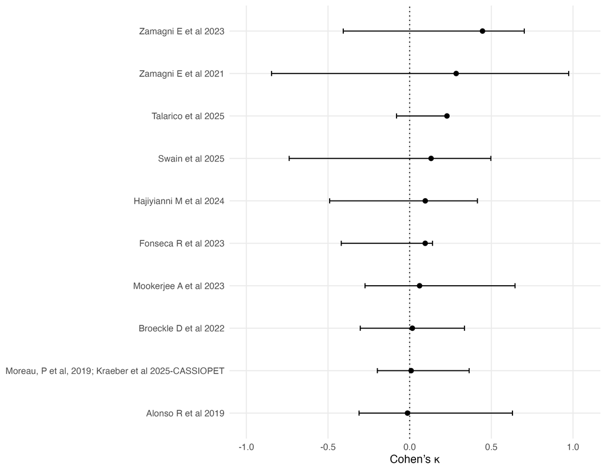

Supplementary Methods S3 – κ identification intervals (Fréchet–Hoeffding bounds) with point estimate

## 3.3 Figure 2A. Weighted Forest Plot

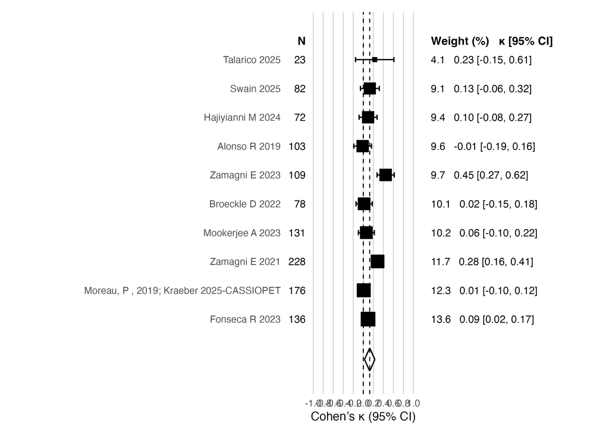

## 3.4 Figure 2B (PRIMARY)

[figure not shown]

B. Directional discordance (PRIMARY) — Lancet style

## 3.5 Figure 2B (STRICT, Δ≤30): Directional discordance meta-analysis

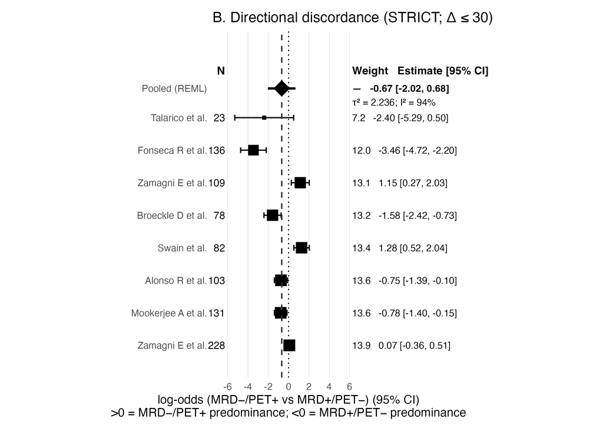

Figure 2B (STRICT; Δ ≤ 30) — Directional discordance

## 3.6 Supplementary Figure SF1. Concordance matrix (pooled)

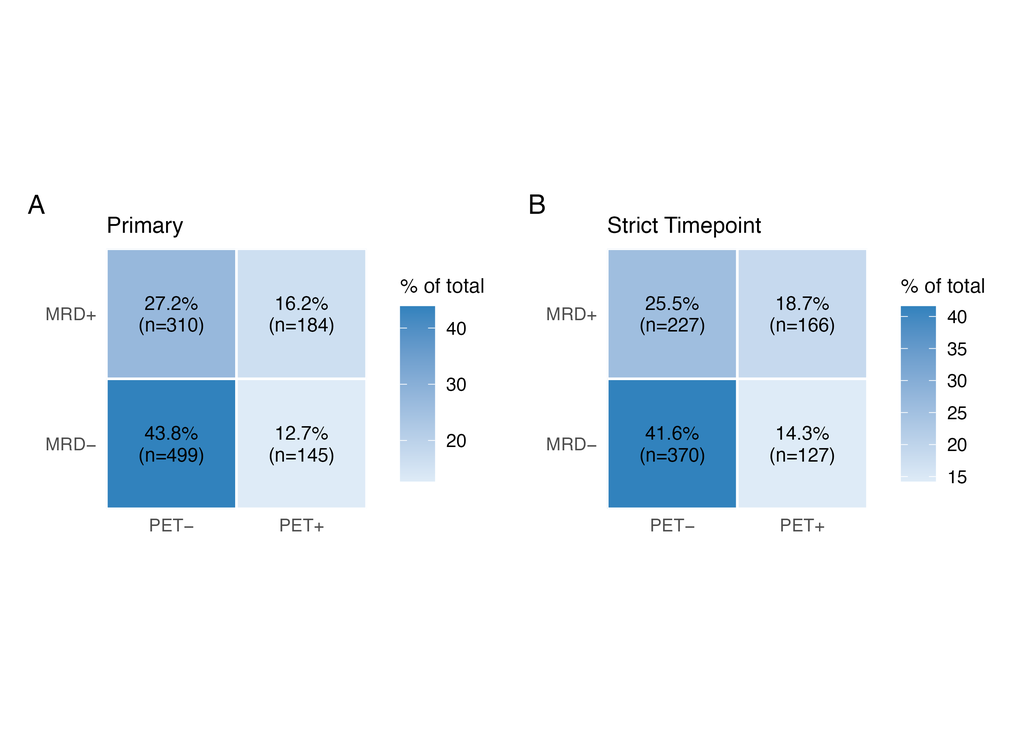

Supplementary Figure SF1. Concordance matrices for PRIMARY and STRICT time-points. STRICT applies the Δ(MRD–PET) ≤ 30 days rule to treat assessments as paired.

## 3.7 Supplementary Figure SF2. Discordance Strict Analysis

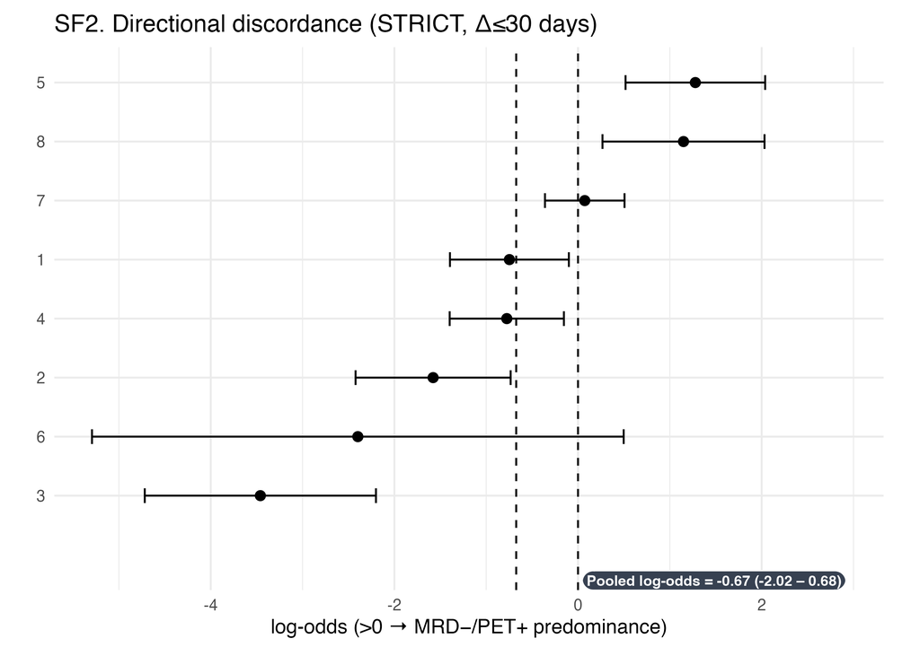

[output not shown]

# 4 Survival & meta-analysis

## 4.1 PFS Dual-negative vs others

PFS dual-negative vs others — 5 studies detected

| Study | logHR | SE | HR | HR_lo | HR_hi |
| --- | --- | --- | --- | --- | --- |
| Alonso R, Cedena MT, Gomez-Grande A, Rios R, Moraleda JM, Cabanas V, Moreno MJ, Lopez-Jimenez J, Martin F, Sanz A, Valeri A, Jimenez A, Sanchez R, Lahuerta JJ, Martinez-Lopez J | -1.509 | 0.237 | 0.221 | 0.139 | 0.352 |
| Moreau, P et al, 2019; Kraeber et al 2025 | -0.935 | 0.273 | 0.393 | 0.230 | 0.670 |
| Zamagni E, Oliva S, Gay F, Capra A, Rota-Scalabrini D, D’Agostino M, Belotti A, Galli M, Racca M, Zambello R, Gamberi B, Albano D, Bertamini L, Versari A, Grasso M, Sgherza N, Priola C, Fioritoni F, P… | -0.799 | 0.342 | 0.450 | 0.230 | 0.880 |
| Mookerjee A, Gupta R, Kumar R, Sharma A, Pandey RM, Kumar L | -1.151 | 0.234 | 0.316 | 0.200 | 0.500 |
| Fonseca R, Arribas M, Wiedmeier-Nutor JE, et al. | -0.564 | 0.485 | 0.569 | 0.220 | 1.470 |

## 4.2 Figure 3. Forest:dual-negativity

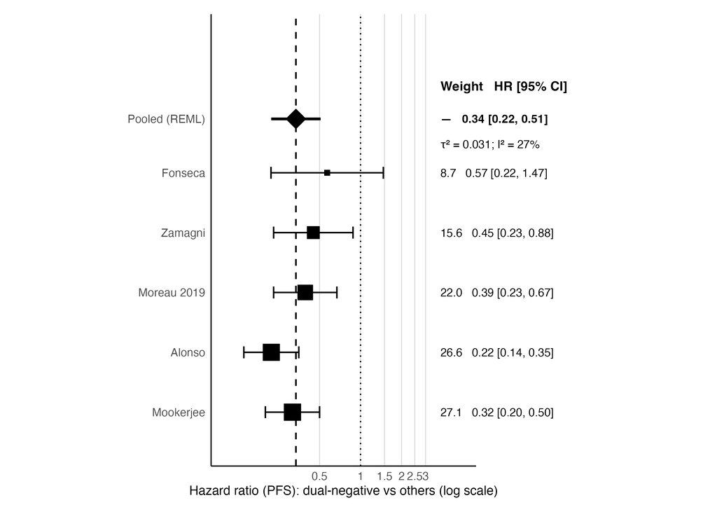

Figure 3. Dual-negative MRD−/PET-CT− versus all other states: pooled hazard ratio for progression-free survival

*Hazard ratios compare **dual‑negative (MRD−/PET−)** versus **all other states**. HRs and 95% CIs were used as reported when available; otherwise standardized from text fields or reconstructed from the reported CI on the log scale (normal approximation). Values < 1 favor dual‑negative; > 1 favor others. Pooling uses random‑effects REML with Knapp–Hartung; a prediction interval is shown when k ≥ 2.*

## 4.3 PFS pooled summary

**PFS pooled summary (dual-negative vs all others)**

Random-effects REML with Knapp–Hartung. Values < 1 favor dual-negative.

| Model | k | HR (95% CI) | Prediction interval (HR) | τ² | I² (%) |
| --- | --- | --- | --- | --- | --- |
| REML (Knapp–Hartung) | 5 | 0.34 (0.22–0.51) | 0.18–0.64 | 0.03 | 26.73 |

Small-study asymmetry tests have low power when *k* < 10; interpret cautiously.

## 4.4 Figure 3B. Funnel plot

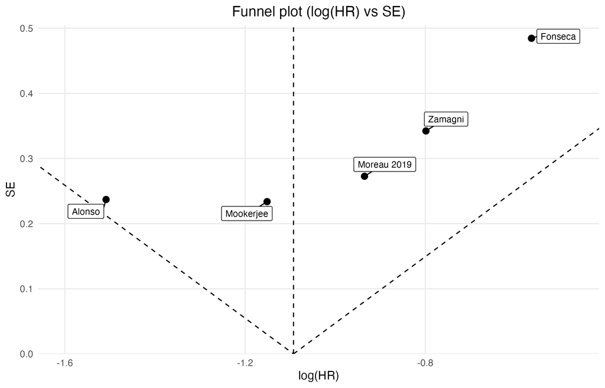

```r
stopifnot(exists("surv_df"), nrow(surv_df) >= 1)

if (!exists("res_hr") || !inherits(res_hr, "rma.uni")) {
  res_hr <- metafor::rma(yi = surv_df$logHR, vi = surv_df$vi, method = "REML", test = "knha")
}
mu <- as.numeric(res_hr$b)

egger_p <- NA_real_
if (nrow(surv_df) >= 3) {
  eg <- metafor::regtest(res_hr, model = "rma")
  egger_p <- eg$pval
}
egger_lab <- if (is.finite(egger_p)) sprintf("Egger p = %.3f", egger_p) else "Egger p = NA"
# --------------------------------------------


# Limits from data to include ALL studies
x_min <- min(surv_df$logHR, na.rm = TRUE) - 0.15
x_max <- max(surv_df$logHR, na.rm = TRUE) + 0.15
y_max <- max(surv_df$SE,    na.rm = TRUE) + 0.02
y_seq <- seq(0, y_max, length.out = 200)

cone_left  <- data.frame(x = mu - 1.96*y_seq, y = y_seq)
cone_right <- data.frame(x = mu + 1.96*y_seq, y = y_seq)

p_fun <- ggplot(surv_df, aes(x = logHR, y = SE)) +
  geom_line(data = cone_left,  aes(x, y), linetype = "dashed") +
  geom_line(data = cone_right, aes(x, y), linetype = "dashed") +
  geom_vline(xintercept = mu, linetype = "dashed") +
  geom_point(size = 2.5) +
  ggrepel::geom_label_repel(aes(label = StudyShort),
                            size = 3, label.size = 0.25,
                            label.r = grid::unit(0.08, "lines"),  # <- change unit() -> grid::unit()
                            min.segment.length = 0, seed = 1234) +
coord_cartesian(xlim = c(x_min, x_max), expand = FALSE) +
  labs(x = "log(HR)", y = "SE", title = "Funnel plot (log(HR) vs SE)") +
annotate("text", x = x_max, y = y_max, hjust = 1.1, vjust = -0.5, label = egger_lab, size = 3) +
  theme_minimal(base_size = 11) +
  theme(panel.grid.minor = element_blank(),
        plot.title = element_text(hjust = 0.5))

out_png <- here::here("figs","Figure_3B_Funnel.png")
ggsave(out_png, p_fun, width = 7.8, height = 5.0, dpi = 300, bg = "white")

cap <- if (exists("legend_for")) legend_for("Figure_3B_Funnel.png") else
  "B. Funnel plot (log(HR) vs SE). Dashed cone = ~95% pseudo-CIs; vertical line = pooled effect; Egger’s p shown; for k<10 interpret with caution."
if (file.exists(out_png)) { if (exists("show_png")) show_png("figs", basename(out_png), caption = cap, width = "95%") else knitr::include_graphics(out_png) }
```

## 4.5 Supplementary Figure SF3

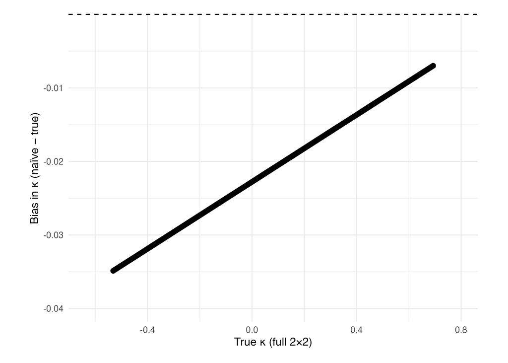

## 4.6 Supplementary Table ST2 (Leave-one-out, Egger table, Baujat)

**ST2: Egger summary — PFS HR (dual−negative vs others)**

| model | k | center_log | Egger_p |
| --- | --- | --- | --- |
| REML (Knapp–Hartung) | 5.000 | −1.093 | 0.119 |

*Egger’s test has low power for k < 10; interpret with caution.*

**Leave-one-out (sorted by |Δ pooled|)**

| Study | Center | LOO_est | LOO_se | Delta | LCL | UCL | HR_center | HR | HR_LCL | HR_UCL |
| --- | --- | --- | --- | --- | --- | --- | --- | --- | --- | --- |
| Alonso | −1.093 | −0.962 | 0.108 | 0.130 | −1.175 | −0.750 | 0.335 | 0.382 | 0.309 | 0.472 |
| Zamagni | −1.093 | −1.147 | 0.171 | 0.055 | −1.483 | −0.812 | 0.335 | 0.318 | 0.227 | 0.444 |
| Fonseca | −1.093 | −1.146 | 0.152 | 0.053 | −1.444 | −0.848 | 0.335 | 0.318 | 0.236 | 0.428 |
| Mookerjee | −1.093 | −1.041 | 0.202 | 0.051 | −1.437 | −0.646 | 0.335 | 0.353 | 0.238 | 0.524 |
| Moreau 2019 | −1.093 | −1.121 | 0.192 | 0.029 | −1.497 | −0.745 | 0.335 | 0.326 | 0.224 | 0.475 |

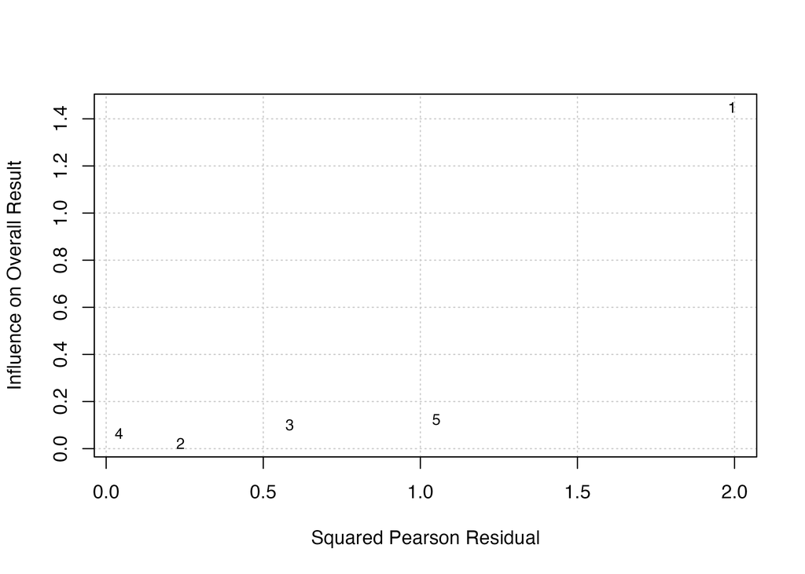

Baujat plot

```
           x          y ids slab
1 1.99245249 1.44781779   1    1
2 0.23620252 0.02205887   2    2
3 0.58403678 0.10144991   3    3
4 0.04032006 0.06436193   4    4
5 1.05091602 0.12297498   5    5
```

## 4.7 Risk of Bias: import & quick previews

#QUIPS / QUADAS-2: setup, templates, and import

# 5 Traffic-light plots (QUIPS & QUADAS-2) + domain summaries

[figure not shown]

# 6 Concordance (QUADAS-2): annotate plots and do sensitivity

```
Sensitivity (exclude QUADAS-2 High): κ = 0.163 (0.103–0.224)
```

# 7 Risk of Bias

[figure not shown]

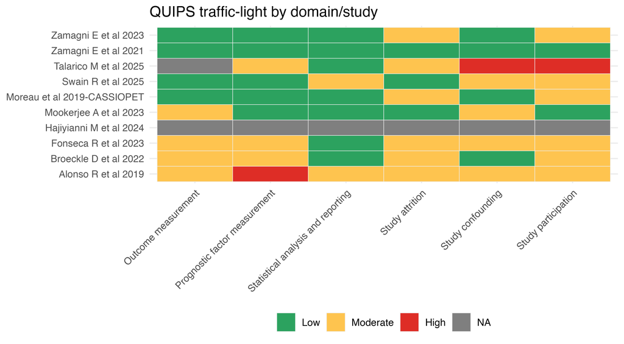

[figure not shown]

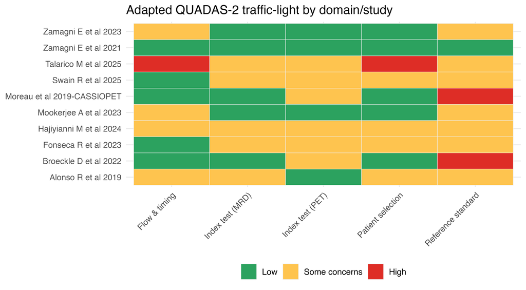

[figure not shown]